# Part I - Dataset Exploration - Ford GoBikes.

## 1. Introduction

> This project has two parts that illustrates the importance and value of data visualization tools in the data analysis process. This is a Capstone project, part of the Udacity Data Analysis Nanodegree course.

> In this part, I will use Python libraries to wrangle and explore a `201902-fordgobike-tripdata.csv` datafile, starting from vieweing single variables to plots of multiple variables.

> In the following second part of the project, I will produce a short presentation that illustrates interesting properties, trends, and relationships that I discovered in the cleaned dataset I exported.

### 1.1 Dataset and its origin

Bay Wheels is the Bay Area's regional bike share program serving Berkeley, Emeryville, Oakland, San Jose and San Francisco. Bay Wheels offers convenient, healthy, climate-friendly transportation around the Bay Area.

Bay Wheels offers over 7,000 bicycles (both traditional bikes and hybrid electric bikes) at 550 stations:

> Pedal-powered bikes can be picked up and dropped off at Bay Wheels docking stations

> E-bikes can use the docking stations or can be locked to a city bike rack

This data set includes information about individual rides made in a bike-sharing system covering the greater San Francisco Bay area during 1`February 2019`. The dataset can be downloaded [here](https://video.udacity-data.com/topher/2020/October/5f91cf38_201902-fordgobike-tripdata/201902-fordgobike-tripdata.csv)

#### The dataset has columns:

- Duration_sec
- Start_time
- End_time
- Start_station_id
- Start_station_name
- Start_station_latitude
- Start_station_longitude
- End_station_id
- End_station_name
- End_station_latitude
- End_station_longitude
- Bike_id
- User_type
- Member_birth_year
- Member_gender
- Bike_share_for_all_trip

```python
# import all packages and set plots to be embedded inline
import numpy as np
import pandas as pd
import matplotlib.pyplot as plt
import seaborn as sb

%matplotlib inline
```

```python
import warnings
warnings.filterwarnings('ignore')
```

> Load in your dataset and describe its properties through the questions below. Try and motivate your exploration goals through this section.

## 2. Data Gathering

```python
gobikes = pd.read_csv('201902-fordgobike-tripdata.csv')
gobikes.sample(10)
```

|  | duration_sec | start_time | end_time | start_station_id | start_station_name | start_station_latitude | start_station_longitude | end_station_id | end_station_name | end_station_latitude | end_station_longitude | bike_id | user_type | member_birth_year | member_gender | bike_share_for_all_trip |
| --- | --- | --- | --- | --- | --- | --- | --- | --- | --- | --- | --- | --- | --- | --- | --- | --- |
| 89695 | 1714 | 2019-02-16 14:32:22.1870 | 2019-02-16 15:00:56.7930 | 53.0 | Grove St at Divisadero | 37.775946 | -122.437777 | 27.0 | Beale St at Harrison St | 37.788059 | -122.391865 | 6591 | Subscriber | 1993.0 | Male | No |
| 128478 | 396 | 2019-02-10 13:11:27.1000 | 2019-02-10 13:18:03.2810 | 16.0 | Steuart St at Market St | 37.794130 | -122.394430 | 323.0 | Broadway at Kearny | 37.798014 | -122.405950 | 4381 | Subscriber | 1989.0 | Male | No |
| 109596 | 217 | 2019-02-12 18:55:31.3000 | 2019-02-12 18:59:08.9420 | 245.0 | Downtown Berkeley BART | 37.870139 | -122.268422 | 247.0 | Fulton St at Bancroft Way | 37.867789 | -122.265896 | 5075 | Subscriber | 1996.0 | Female | Yes |
| 20577 | 335 | 2019-02-26 11:56:08.4840 | 2019-02-26 12:01:43.7500 | 50.0 | 2nd St at Townsend St | 37.780526 | -122.390288 | 26.0 | 1st St at Folsom St | 37.787290 | -122.394380 | 4733 | Subscriber | 1995.0 | Male | No |
| 174580 | 2300 | 2019-02-02 17:01:52.0180 | 2019-02-02 17:40:12.2720 | 377.0 | Fell St at Stanyan St | 37.771917 | -122.453704 | 119.0 | 18th St at Noe St | 37.761047 | -122.432642 | 5220 | Subscriber | 1996.0 | Male | No |
| 105350 | 1482 | 2019-02-14 06:42:29.6190 | 2019-02-14 07:07:11.9120 | 141.0 | Valencia St at Cesar Chavez St | 37.747998 | -122.420219 | 14.0 | Clay St at Battery St | 37.795001 | -122.399970 | 5164 | Subscriber | 1993.0 | Male | No |
| 39522 | 530 | 2019-02-23 08:40:28.3960 | 2019-02-23 08:49:18.9260 | 246.0 | Berkeley Civic Center | 37.869060 | -122.270556 | 266.0 | Parker St at Fulton St | 37.862464 | -122.264791 | 5641 | Subscriber | 1976.0 | Female | Yes |
| 62738 | 988 | 2019-02-20 16:22:36.9470 | 2019-02-20 16:39:05.7850 | 13.0 | Commercial St at Montgomery St | 37.794231 | -122.402923 | 370.0 | Jones St at Post St | 37.787327 | -122.413278 | 6229 | Subscriber | 1977.0 | Male | Yes |
| 135579 | 2159 | 2019-02-08 11:55:56.7590 | 2019-02-08 12:31:56.6980 | 246.0 | Berkeley Civic Center | 37.869060 | -122.270556 | 241.0 | Ashby BART Station | 37.852477 | -122.270213 | 5156 | Subscriber | 1998.0 | Male | No |
| 102288 | 319 | 2019-02-14 16:44:08.7860 | 2019-02-14 16:49:27.9160 | 100.0 | Bryant St at 15th St | 37.767100 | -122.410662 | 67.0 | San Francisco Caltrain Station 2 (Townsend St... | 37.776639 | -122.395526 | 5137 | Subscriber | 1977.0 | Male | No |

## 3. Data assessing

```python
gobikes.head()
```

|  | duration_sec | start_time | end_time | start_station_id | start_station_name | start_station_latitude | start_station_longitude | end_station_id | end_station_name | end_station_latitude | end_station_longitude | bike_id | user_type | member_birth_year | member_gender | bike_share_for_all_trip |
| --- | --- | --- | --- | --- | --- | --- | --- | --- | --- | --- | --- | --- | --- | --- | --- | --- |
| 0 | 52185 | 2019-02-28 17:32:10.1450 | 2019-03-01 08:01:55.9750 | 21.0 | Montgomery St BART Station (Market St at 2nd St) | 37.789625 | -122.400811 | 13.0 | Commercial St at Montgomery St | 37.794231 | -122.402923 | 4902 | Customer | 1984.0 | Male | No |
| 1 | 42521 | 2019-02-28 18:53:21.7890 | 2019-03-01 06:42:03.0560 | 23.0 | The Embarcadero at Steuart St | 37.791464 | -122.391034 | 81.0 | Berry St at 4th St | 37.775880 | -122.393170 | 2535 | Customer | NaN | NaN | No |
| 2 | 61854 | 2019-02-28 12:13:13.2180 | 2019-03-01 05:24:08.1460 | 86.0 | Market St at Dolores St | 37.769305 | -122.426826 | 3.0 | Powell St BART Station (Market St at 4th St) | 37.786375 | -122.404904 | 5905 | Customer | 1972.0 | Male | No |
| 3 | 36490 | 2019-02-28 17:54:26.0100 | 2019-03-01 04:02:36.8420 | 375.0 | Grove St at Masonic Ave | 37.774836 | -122.446546 | 70.0 | Central Ave at Fell St | 37.773311 | -122.444293 | 6638 | Subscriber | 1989.0 | Other | No |
| 4 | 1585 | 2019-02-28 23:54:18.5490 | 2019-03-01 00:20:44.0740 | 7.0 | Frank H Ogawa Plaza | 37.804562 | -122.271738 | 222.0 | 10th Ave at E 15th St | 37.792714 | -122.248780 | 4898 | Subscriber | 1974.0 | Male | Yes |

```python
gobikes.info()
```

```
<class 'pandas.core.frame.DataFrame'>
RangeIndex: 183412 entries, 0 to 183411
Data columns (total 16 columns):
 #   Column                   Non-Null Count   Dtype
---  ------                   --------------   -----
 0   duration_sec             183412 non-null  int64
 1   start_time               183412 non-null  object
 2   end_time                 183412 non-null  object
 3   start_station_id         183215 non-null  float64
 4   start_station_name       183215 non-null  object
 5   start_station_latitude   183412 non-null  float64
 6   start_station_longitude  183412 non-null  float64
 7   end_station_id           183215 non-null  float64
 8   end_station_name         183215 non-null  object
 9   end_station_latitude     183412 non-null  float64
 10  end_station_longitude    183412 non-null  float64
 11  bike_id                  183412 non-null  int64
 12  user_type                183412 non-null  object
 13  member_birth_year        175147 non-null  float64
 14  member_gender            175147 non-null  object
 15  bike_share_for_all_trip  183412 non-null  object
dtypes: float64(7), int64(2), object(7)
memory usage: 22.4+ MB
```

```python
gobikes.describe()
```

|  | duration_sec | start_station_id | start_station_latitude | start_station_longitude | end_station_id | end_station_latitude | end_station_longitude | bike_id | member_birth_year |
| --- | --- | --- | --- | --- | --- | --- | --- | --- | --- |
| count | 183412.000000 | 183215.000000 | 183412.000000 | 183412.000000 | 183215.000000 | 183412.000000 | 183412.000000 | 183412.000000 | 175147.000000 |
| mean | 726.078435 | 138.590427 | 37.771223 | -122.352664 | 136.249123 | 37.771427 | -122.352250 | 4472.906375 | 1984.806437 |
| std | 1794.389780 | 111.778864 | 0.099581 | 0.117097 | 111.515131 | 0.099490 | 0.116673 | 1664.383394 | 10.116689 |
| min | 61.000000 | 3.000000 | 37.317298 | -122.453704 | 3.000000 | 37.317298 | -122.453704 | 11.000000 | 1878.000000 |
| 25% | 325.000000 | 47.000000 | 37.770083 | -122.412408 | 44.000000 | 37.770407 | -122.411726 | 3777.000000 | 1980.000000 |
| 50% | 514.000000 | 104.000000 | 37.780760 | -122.398285 | 100.000000 | 37.781010 | -122.398279 | 4958.000000 | 1987.000000 |
| 75% | 796.000000 | 239.000000 | 37.797280 | -122.286533 | 235.000000 | 37.797320 | -122.288045 | 5502.000000 | 1992.000000 |
| max | 85444.000000 | 398.000000 | 37.880222 | -121.874119 | 398.000000 | 37.880222 | -121.874119 | 6645.000000 | 2001.000000 |

```python
gobikes.shape
```

```
(183412, 16)
```

```python
gobikes['end_station_name'].value_counts()
```

```
San Francisco Caltrain Station 2  (Townsend St at 4th St)    4857
Market St at 10th St                                         3973
Montgomery St BART Station (Market St at 2nd St)             3647
San Francisco Ferry Building (Harry Bridges Plaza)           3368
Powell St BART Station (Market St at 4th St)                 2997
                                                             ...
Parker Ave at McAllister St                                     9
Palm St at Willow St                                            7
16th St Depot                                                   6
21st Ave at International Blvd                                  6
Willow St at Vine St                                            5
Name: end_station_name, Length: 329, dtype: int64
```

```python
gobikes.info()
```

```
<class 'pandas.core.frame.DataFrame'>
RangeIndex: 183412 entries, 0 to 183411
Data columns (total 16 columns):
 #   Column                   Non-Null Count   Dtype
---  ------                   --------------   -----
 0   duration_sec             183412 non-null  int64
 1   start_time               183412 non-null  object
 2   end_time                 183412 non-null  object
 3   start_station_id         183215 non-null  float64
 4   start_station_name       183215 non-null  object
 5   start_station_latitude   183412 non-null  float64
 6   start_station_longitude  183412 non-null  float64
 7   end_station_id           183215 non-null  float64
 8   end_station_name         183215 non-null  object
 9   end_station_latitude     183412 non-null  float64
 10  end_station_longitude    183412 non-null  float64
 11  bike_id                  183412 non-null  int64
 12  user_type                183412 non-null  object
 13  member_birth_year        175147 non-null  float64
 14  member_gender            175147 non-null  object
 15  bike_share_for_all_trip  183412 non-null  object
dtypes: float64(7), int64(2), object(7)
memory usage: 22.4+ MB
```

```python
# null values in dataset sum:
gobikes.isnull().sum()
```

```
duration_sec                  0
start_time                    0
end_time                      0
start_station_id            197
start_station_name          197
start_station_latitude        0
start_station_longitude       0
end_station_id              197
end_station_name            197
end_station_latitude          0
end_station_longitude         0
bike_id                       0
user_type                     0
member_birth_year          8265
member_gender              8265
bike_share_for_all_trip       0
dtype: int64
```

```python
gobikes.dtypes
```

```
duration_sec                 int64
start_time                  object
end_time                    object
start_station_id           float64
start_station_name          object
start_station_latitude     float64
start_station_longitude    float64
end_station_id             float64
end_station_name            object
end_station_latitude       float64
end_station_longitude      float64
bike_id                      int64
user_type                   object
member_birth_year          float64
member_gender               object
bike_share_for_all_trip     object
dtype: object
```

```python
gobikes.member_birth_year.sort_values()
```

```
27370     1878.0
72711     1900.0
41319     1900.0
173711    1900.0
94616     1900.0
           ...
183354       NaN
183356       NaN
183363       NaN
183371       NaN
183402       NaN
Name: member_birth_year, Length: 183412, dtype: float64
```

```python
# no duplicates
gobikes.duplicated().sum()
```

```
0
```

### Summary of identified Quality and Tidiness issues

##### Quality issues

1. starttime and endtime have the wrong datatype string (in stead of datetime)
2. user_type has wrong datatype string (in stead of categorical)
3. Null Values in some columns
4. Odd year for a row in member_birth_year

##### Tidiness issues

1. Create column for duration_min, start day etc

## 4. Data Cleaning

#### First make copy of dataframes before cleaning

```python
# Make copy of dataframe
clean_bikes = gobikes.copy()
```

```python
clean_bikes.info()
```

```
<class 'pandas.core.frame.DataFrame'>
RangeIndex: 183412 entries, 0 to 183411
Data columns (total 16 columns):
 #   Column                   Non-Null Count   Dtype
---  ------                   --------------   -----
 0   duration_sec             183412 non-null  int64
 1   start_time               183412 non-null  object
 2   end_time                 183412 non-null  object
 3   start_station_id         183215 non-null  float64
 4   start_station_name       183215 non-null  object
 5   start_station_latitude   183412 non-null  float64
 6   start_station_longitude  183412 non-null  float64
 7   end_station_id           183215 non-null  float64
 8   end_station_name         183215 non-null  object
 9   end_station_latitude     183412 non-null  float64
 10  end_station_longitude    183412 non-null  float64
 11  bike_id                  183412 non-null  int64
 12  user_type                183412 non-null  object
 13  member_birth_year        175147 non-null  float64
 14  member_gender            175147 non-null  object
 15  bike_share_for_all_trip  183412 non-null  object
dtypes: float64(7), int64(2), object(7)
memory usage: 22.4+ MB
```

### Issue #1: Quality: starttime and endtime have the wrong datatype string (instead of datetime)

#### Define

- Change both columns to datetime

#### Code

```python
clean_bikes['start_time'] = pd.to_datetime(clean_bikes['start_time'])
clean_bikes['end_time'] = pd.to_datetime(clean_bikes['end_time'])
```

#### Test

```python
clean_bikes.info()
```

```
<class 'pandas.core.frame.DataFrame'>
RangeIndex: 183412 entries, 0 to 183411
Data columns (total 16 columns):
 #   Column                   Non-Null Count   Dtype
---  ------                   --------------   -----
 0   duration_sec             183412 non-null  int64
 1   start_time               183412 non-null  datetime64[ns]
 2   end_time                 183412 non-null  datetime64[ns]
 3   start_station_id         183215 non-null  float64
 4   start_station_name       183215 non-null  object
 5   start_station_latitude   183412 non-null  float64
 6   start_station_longitude  183412 non-null  float64
 7   end_station_id           183215 non-null  float64
 8   end_station_name         183215 non-null  object
 9   end_station_latitude     183412 non-null  float64
 10  end_station_longitude    183412 non-null  float64
 11  bike_id                  183412 non-null  int64
 12  user_type                183412 non-null  object
 13  member_birth_year        175147 non-null  float64
 14  member_gender            175147 non-null  object
 15  bike_share_for_all_trip  183412 non-null  object
dtypes: datetime64[ns](2), float64(7), int64(2), object(5)
memory usage: 22.4+ MB
```

### Issue #2: Quality: user_type has wrong datatype string (instead of categorical)

#### Define:

- convert user_type type from string to categorical

#### Code

```python
clean_bikes['user_type'] = clean_bikes['user_type'].astype('category')
```

#### Test

```python
clean_bikes.info()
```

```
<class 'pandas.core.frame.DataFrame'>
RangeIndex: 183412 entries, 0 to 183411
Data columns (total 16 columns):
 #   Column                   Non-Null Count   Dtype
---  ------                   --------------   -----
 0   duration_sec             183412 non-null  int64
 1   start_time               183412 non-null  datetime64[ns]
 2   end_time                 183412 non-null  datetime64[ns]
 3   start_station_id         183215 non-null  float64
 4   start_station_name       183215 non-null  object
 5   start_station_latitude   183412 non-null  float64
 6   start_station_longitude  183412 non-null  float64
 7   end_station_id           183215 non-null  float64
 8   end_station_name         183215 non-null  object
 9   end_station_latitude     183412 non-null  float64
 10  end_station_longitude    183412 non-null  float64
 11  bike_id                  183412 non-null  int64
 12  user_type                183412 non-null  category
 13  member_birth_year        175147 non-null  float64
 14  member_gender            175147 non-null  object
 15  bike_share_for_all_trip  183412 non-null  object
dtypes: category(1), datetime64[ns](2), float64(7), int64(2), object(4)
memory usage: 21.2+ MB
```

### Issue #3: Quality Null Values in some columns

#### Define:

- drop rows with null values

#### Code

```python
clean_bikes.dropna(inplace=True)
```

#### Test

```python
clean_bikes.isnull().sum()
```

```
duration_sec               0
start_time                 0
end_time                   0
start_station_id           0
start_station_name         0
start_station_latitude     0
start_station_longitude    0
end_station_id             0
end_station_name           0
end_station_latitude       0
end_station_longitude      0
bike_id                    0
user_type                  0
member_birth_year          0
member_gender              0
bike_share_for_all_trip    0
dtype: int64
```

```python
clean_bikes.info()
```

```
<class 'pandas.core.frame.DataFrame'>
Int64Index: 174952 entries, 0 to 183411
Data columns (total 16 columns):
 #   Column                   Non-Null Count   Dtype
---  ------                   --------------   -----
 0   duration_sec             174952 non-null  int64
 1   start_time               174952 non-null  datetime64[ns]
 2   end_time                 174952 non-null  datetime64[ns]
 3   start_station_id         174952 non-null  float64
 4   start_station_name       174952 non-null  object
 5   start_station_latitude   174952 non-null  float64
 6   start_station_longitude  174952 non-null  float64
 7   end_station_id           174952 non-null  float64
 8   end_station_name         174952 non-null  object
 9   end_station_latitude     174952 non-null  float64
 10  end_station_longitude    174952 non-null  float64
 11  bike_id                  174952 non-null  int64
 12  user_type                174952 non-null  category
 13  member_birth_year        174952 non-null  float64
 14  member_gender            174952 non-null  object
 15  bike_share_for_all_trip  174952 non-null  object
dtypes: category(1), datetime64[ns](2), float64(7), int64(2), object(4)
memory usage: 21.5+ MB
```

### Issue #4: Quality: Odd year for a row in member_birth_year

#### Define:

- drop row with odd year

#### Code

```python
clean_bikes[clean_bikes.member_birth_year == 1878]
```

|  | duration_sec | start_time | end_time | start_station_id | start_station_name | start_station_latitude | start_station_longitude | end_station_id | end_station_name | end_station_latitude | end_station_longitude | bike_id | user_type | member_birth_year | member_gender | bike_share_for_all_trip |
| --- | --- | --- | --- | --- | --- | --- | --- | --- | --- | --- | --- | --- | --- | --- | --- | --- |
| 27370 | 1474 | 2019-02-25 09:28:42.161 | 2019-02-25 09:53:17.068 | 15.0 | San Francisco Ferry Building (Harry Bridges Pl... | 37.795392 | -122.394203 | 386.0 | 24th St at Bartlett St | 37.752105 | -122.419724 | 6436 | Customer | 1878.0 | Female | No |

```python
clean_bikes.drop(27370, inplace = True)
```

#### Test

```python
clean_bikes.member_birth_year.sort_values()
```

```
27675     1900.0
34747     1900.0
93193     1900.0
21506     1900.0
107359    1900.0
           ...
63137     2001.0
65310     2001.0
39355     2001.0
176045    2001.0
45335     2001.0
Name: member_birth_year, Length: 174951, dtype: float64
```

```python
clean_bikes.info()
```

```
<class 'pandas.core.frame.DataFrame'>
Int64Index: 174951 entries, 0 to 183411
Data columns (total 16 columns):
 #   Column                   Non-Null Count   Dtype
---  ------                   --------------   -----
 0   duration_sec             174951 non-null  int64
 1   start_time               174951 non-null  datetime64[ns]
 2   end_time                 174951 non-null  datetime64[ns]
 3   start_station_id         174951 non-null  float64
 4   start_station_name       174951 non-null  object
 5   start_station_latitude   174951 non-null  float64
 6   start_station_longitude  174951 non-null  float64
 7   end_station_id           174951 non-null  float64
 8   end_station_name         174951 non-null  object
 9   end_station_latitude     174951 non-null  float64
 10  end_station_longitude    174951 non-null  float64
 11  bike_id                  174951 non-null  int64
 12  user_type                174951 non-null  category
 13  member_birth_year        174951 non-null  float64
 14  member_gender            174951 non-null  object
 15  bike_share_for_all_trip  174951 non-null  object
dtypes: category(1), datetime64[ns](2), float64(7), int64(2), object(4)
memory usage: 21.5+ MB
```

### Issue #5: Tidiness: Create column for duration_min, start day etc

#### Define:

- To complete investigations, create column for duration_min, start day etc

#### Code

```python
# Extract age, minute,day,week,month from the start_time
clean_bikes['duration_min'] = clean_bikes['duration_sec']/60

#Creating a variable for the base year
year = 2019

clean_bikes['Date'] = clean_bikes.start_time.dt.strftime('%Y-%m-%d')
clean_bikes['Hour_of_day'] = clean_bikes.start_time.dt.strftime('%H')
clean_bikes['Day_of_week'] = clean_bikes.start_time.dt.strftime('%A')
clean_bikes['Age'] = (year - clean_bikes['member_birth_year']).astype(int)
```

#### Test

```python
clean_bikes.info()
```

```
<class 'pandas.core.frame.DataFrame'>
Int64Index: 174951 entries, 0 to 183411
Data columns (total 21 columns):
 #   Column                   Non-Null Count   Dtype
---  ------                   --------------   -----
 0   duration_sec             174951 non-null  int64
 1   start_time               174951 non-null  datetime64[ns]
 2   end_time                 174951 non-null  datetime64[ns]
 3   start_station_id         174951 non-null  float64
 4   start_station_name       174951 non-null  object
 5   start_station_latitude   174951 non-null  float64
 6   start_station_longitude  174951 non-null  float64
 7   end_station_id           174951 non-null  float64
 8   end_station_name         174951 non-null  object
 9   end_station_latitude     174951 non-null  float64
 10  end_station_longitude    174951 non-null  float64
 11  bike_id                  174951 non-null  int64
 12  user_type                174951 non-null  category
 13  member_birth_year        174951 non-null  float64
 14  member_gender            174951 non-null  object
 15  bike_share_for_all_trip  174951 non-null  object
 16  duration_min             174951 non-null  float64
 17  Date                     174951 non-null  object
 18  Hour_of_day              174951 non-null  object
 19  Day_of_week              174951 non-null  object
 20  Age                      174951 non-null  int32
dtypes: category(1), datetime64[ns](2), float64(8), int32(1), int64(2), object(7)
memory usage: 31.6+ MB
```

```python
clean_bikes.describe()
```

|  | duration_sec | start_station_id | start_station_latitude | start_station_longitude | end_station_id | end_station_latitude | end_station_longitude | bike_id | member_birth_year | duration_min | Age |
| --- | --- | --- | --- | --- | --- | --- | --- | --- | --- | --- | --- |
| count | 174951.000000 | 174951.000000 | 174951.000000 | 174951.000000 | 174951.000000 | 174951.000000 | 174951.000000 | 174951.000000 | 174951.000000 | 174951.000000 | 174951.000000 |
| mean | 703.998342 | 139.002835 | 37.771220 | -122.351760 | 136.603060 | 37.771414 | -122.351335 | 4482.576390 | 1984.803745 | 11.733306 | 34.196255 |
| std | 1642.208567 | 111.648744 | 0.100391 | 0.117732 | 111.334357 | 0.100296 | 0.117294 | 1659.194107 | 10.115538 | 27.370143 | 10.115538 |
| min | 61.000000 | 3.000000 | 37.317298 | -122.453704 | 3.000000 | 37.317298 | -122.453704 | 11.000000 | 1900.000000 | 1.016667 | 18.000000 |
| 25% | 323.000000 | 47.000000 | 37.770407 | -122.411901 | 44.000000 | 37.770407 | -122.411647 | 3799.000000 | 1980.000000 | 5.383333 | 27.000000 |
| 50% | 510.000000 | 104.000000 | 37.780760 | -122.398279 | 101.000000 | 37.781010 | -122.397437 | 4960.000000 | 1987.000000 | 8.500000 | 32.000000 |
| 75% | 789.000000 | 239.000000 | 37.797320 | -122.283093 | 238.000000 | 37.797673 | -122.286533 | 5505.000000 | 1992.000000 | 13.150000 | 39.000000 |
| max | 84548.000000 | 398.000000 | 37.880222 | -121.874119 | 398.000000 | 37.880222 | -121.874119 | 6645.000000 | 2001.000000 | 1409.133333 | 119.000000 |

```python
clean_bikes.sample(5)
```

|  | duration_sec | start_time | end_time | start_station_id | start_station_name | start_station_latitude | start_station_longitude | end_station_id | end_station_name | end_station_latitude | ... | bike_id | user_type | member_birth_year | member_gender | bike_share_for_all_trip | duration_min | Date | Hour_of_day | Day_of_week | Age |
| --- | --- | --- | --- | --- | --- | --- | --- | --- | --- | --- | --- | --- | --- | --- | --- | --- | --- | --- | --- | --- | --- |
| 83126 | 318 | 2019-02-18 08:05:54.078 | 2019-02-18 08:11:12.395 | 129.0 | Harrison St at 20th St | 37.758862 | -122.412544 | 114.0 | Rhode Island St at 17th St | 37.764478 | ... | 5464 | Subscriber | 1986.0 | Male | No | 5.300000 | 2019-02-18 | 08 | Monday | 33 |
| 47169 | 412 | 2019-02-22 09:01:12.436 | 2019-02-22 09:08:05.218 | 30.0 | San Francisco Caltrain (Townsend St at 4th St) | 37.776598 | -122.395282 | 284.0 | Yerba Buena Center for the Arts (Howard St at ... | 37.784872 | ... | 5069 | Subscriber | 1989.0 | Male | No | 6.866667 | 2019-02-22 | 09 | Friday | 30 |
| 155547 | 424 | 2019-02-06 08:44:30.275 | 2019-02-06 08:51:34.832 | 55.0 | Webster St at Grove St | 37.777053 | -122.429558 | 43.0 | San Francisco Public Library (Grove St at Hyde... | 37.778768 | ... | 3619 | Subscriber | 1958.0 | Female | No | 7.066667 | 2019-02-06 | 08 | Wednesday | 61 |
| 90404 | 413 | 2019-02-16 12:43:23.986 | 2019-02-16 12:50:17.838 | 321.0 | 5th St at Folsom | 37.780146 | -122.403071 | 58.0 | Market St at 10th St | 37.776619 | ... | 6339 | Subscriber | 1969.0 | Male | Yes | 6.883333 | 2019-02-16 | 12 | Saturday | 50 |
| 161129 | 393 | 2019-02-05 15:57:21.589 | 2019-02-05 16:03:55.187 | 30.0 | San Francisco Caltrain (Townsend St at 4th St) | 37.776598 | -122.395282 | 27.0 | Beale St at Harrison St | 37.788059 | ... | 5573 | Subscriber | 1942.0 | Male | No | 6.550000 | 2019-02-05 | 15 | Tuesday | 77 |

5 rows × 21 columns

#### Export cleaned data to .csv

```python
# save the cleaned data to csv file
clean_bikes.to_csv('201902-fordgobike-tripdata_clean.csv',index=None)
```

### What is the structure of your dataset?

> In this datast, there are 174951 unique trips, with their durations, start time, end time, start station id, end station id, start station name, end station name, bike id , user type, birth year and gender.

### What is/are the main feature(s) of interest in your dataset?

> When are the most trips taken, breaking into hour of the day or day of the week? Also, how does this differ between Customers and Subscribers?

> Does the average duration of a bike trip depend on whether a user is a Subscriber or a Customer?

> What bike station(s) is/are the most popular starting point and destination? Does this correlate with duration?

> What age and gender rent bikes the most, and is there any relationship with these and the duration of the trip?

### What features in the dataset do you think will help support your investigation into your feature(s) of interest?

> user_type trip_duration end_station_name start_time member_birth_year member_gender

## 5. Explorative Data Analysis (EDA)

The analysis in this chapter is structured, going from exploration of simple univariate relationships, to bivariate relationships, up through multivariate relationships.

### 5.1 Univariate Exploration

> In this section, we'll look into the distribution of trips by days of the week, we'll also look into the age and gender that uses bikes the most and the station that is mostly the starting point and the destination.

```python
clean_bikes.Day_of_week.value_counts()
```

```
Thursday     33712
Tuesday      30584
Wednesday    28426
Friday       27663
Monday       25640
Sunday       14512
Saturday     14414
Name: Day_of_week, dtype: int64
```

```python
# Ensuring the Days of the week are in the right order beginning from Monday.

days = ['Monday', 'Tuesday', 'Wednesday', 'Thursday', 'Friday', 'Saturday', 'Sunday']
dailycat = pd.api.types.CategoricalDtype(ordered=True, categories=days)
clean_bikes['Day_of_week'] = clean_bikes['Day_of_week'].astype(dailycat)
```

```python
# Ensuring the Hours of the Day are in the right order beginning from '00'.

hours = ['00', '01', '02', '03', '04', '05', '06', '07', '08', '09', '10', '11', '12', '13', '14', '15', '16', '17', '18', '19', '20', '21', '22', '23']
hrcat = pd.api.types.CategoricalDtype(ordered=True, categories=hours)
clean_bikes['Hour_of day'] = clean_bikes['Hour_of_day'].astype(hrcat)
```

```python
# Setting the base_color
base_color = sb.color_palette()[2]
```

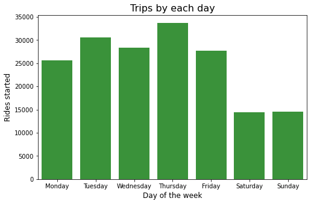

```python
#Plotting a Barchart showing distribution of bike rides per day.

plt.figure(figsize=(8,5))
sb.countplot(data=clean_bikes, x='Day_of_week', color=base_color)
plt.xlabel('Day of the week', fontsize=12)
plt.ylabel('Rides started', fontsize=12)
plt.title("Trips by each day", fontsize=16);
```

- The above Visualization shows that the weekdays are the busiest that trips are mostly done with Thursdays been the highest. This is a common phenomenon as people transit to work and rest on weekends

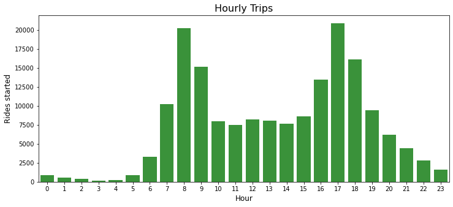

```python
#Plotting a Barchart showing distribution of bike rides per minute of each day.
plt.figure(figsize=(12,5))

sb.countplot(data=clean_bikes, x='Hour_of_day', color=base_color)
plt.xlabel('Hour', fontsize=12)
plt.ylabel('Rides started', fontsize=12)
plt.title('Hourly Trips', fontsize=16);
```

- From the above, the most busy hour is 5 PM, closest to it is 8 AM. The busiest hours are between 7-9 AM and 16-18 PM, this is a common commuting time everywhere.
- There is clearly a high number of bike trips during the peak hours when people go to school or work or they commute from it to home. This makes sense since during the weekends less people have to go to work or study as they do during the workweek.

```python
# Creating a lineplot function.
def lineplot (x, y,  xlabel, ylabel, title):
    '''Plots a lineplot ofthe x and y axes
    x= Value of x axes
    y= Numeric data to represent the x axes
    xlabel = Label of X axes
    ylabel = Label of Y axes'''

    plt.figure(figsize=[20, 10])
    x= x
    y = y
    sb.lineplot(x, y)
    plt.xlabel(xlabel, size= 14)
    plt.ylabel(ylabel, size= 14)
    plt.title(title, size= 14)
    plt.show();
```

#### Plotting the frequency of ages

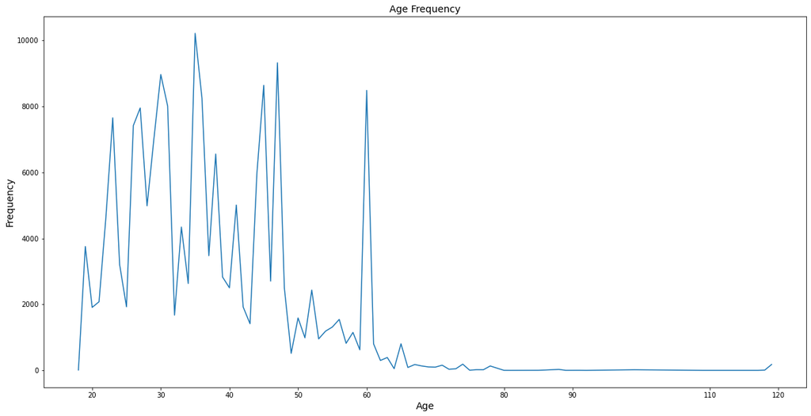

```python
lineplot(clean_bikes['age'].unique(), clean_bikes['age'].value_counts(), 'Age', 'Frequency', 'Age Frequency')
```

#### From the above, we can see that most of the riders are within ages 20 and 60

#### Plotting the frequncy of start stations

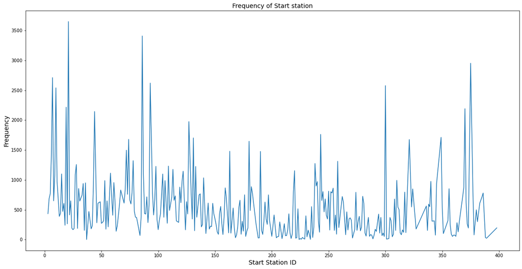

```python
#Plotting the frequency of Start station id.
lineplot(clean_bikes.start_station_id.unique(), clean_bikes.start_station_id.value_counts(), 'Start Station ID', 'Frequency', 'Frequency of Start station')
```

#### The visualization above shows us that some start stations are more frequent than others with a wide spread of frequency inbetween

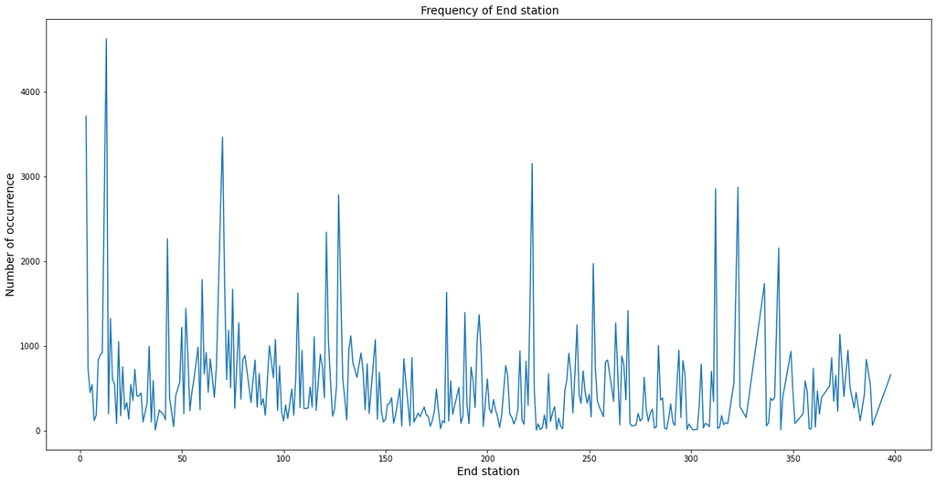

```python
#Plotting the frequency of End station id.
lineplot(clean_bikes.end_station_id.unique(), clean_bikes.end_station_id.value_counts(), 'End station', 'Number of occurrence', ' Frequency of End station')
```

#### From the above, we can see that some end stations are more frequent than some.

> It is also worthy of note that some stations have high frequencies in both start and end stations also in low freqencies, this shows that there is a positive relationship in start and end stations

```python
# Visually see the name of the start_stations that have the most occurrence
clean_bikes.start_station_name.value_counts()
```

```
Market St at 10th St                                         3649
San Francisco Caltrain Station 2  (Townsend St at 4th St)    3408
Berry St at 4th St                                           2952
Montgomery St BART Station (Market St at 2nd St)             2711
Powell St BART Station (Market St at 4th St)                 2620
                                                             ...
Farnam St at Fruitvale Ave                                      9
Parker Ave at McAllister St                                     7
21st Ave at International Blvd                                  4
Palm St at Willow St                                            3
16th St Depot                                                   2
Name: start_station_name, Length: 329, dtype: int64
```

```python
# Visually see the name of the end_stations that have the most occurrence
clean_bikes.end_station_name.value_counts()
```

```
San Francisco Caltrain Station 2  (Townsend St at 4th St)    4624
Market St at 10th St                                         3709
Montgomery St BART Station (Market St at 2nd St)             3461
San Francisco Ferry Building (Harry Bridges Plaza)           3151
San Francisco Caltrain (Townsend St at 4th St)               2870
                                                             ...
Parker Ave at McAllister St                                     9
Palm St at Willow St                                            7
16th St Depot                                                   6
Willow St at Vine St                                            5
21st Ave at International Blvd                                  5
Name: end_station_name, Length: 329, dtype: int64
```

#### Now, I would visualize the top 10 occurring start and end stations.

```python
#Create a Variable that stores the top 10 station and their count
top10_origin = clean_bikes.start_station_name.value_counts()[0:10].sort_values(ascending=False)
top10_origin
```

```
Market St at 10th St                                         3649
San Francisco Caltrain Station 2  (Townsend St at 4th St)    3408
Berry St at 4th St                                           2952
Montgomery St BART Station (Market St at 2nd St)             2711
Powell St BART Station (Market St at 4th St)                 2620
San Francisco Caltrain (Townsend St at 4th St)               2577
San Francisco Ferry Building (Harry Bridges Plaza)           2540
Howard St at Beale St                                        2216
Steuart St at Market St                                      2191
Powell St BART Station (Market St at 5th St)                 2144
Name: start_station_name, dtype: int64
```

```python
# Creats a subplot function that plots a variable against an integer
def subplot(x, y, xlabel, ylabel, title):
    ''' Plots a subplot of the parsed data
    x = value of the x axes
    y = value of y axes
    xlabel =  Label of x axes
    ylabel = Label of Y axes
    title = Title of subplot'''

    figure= plt.figure(figsize=(12,9))
    plt.subplot(2,1,2)
    plt.bar(x.index , y.values)
    plt.ylabel(ylabel , size= 12)
    plt.xlabel(xlabel , size= 12)
    plt.title(title)
    plt.xticks(rotation = 85)

    figure.tight_layout(pad=3)
```

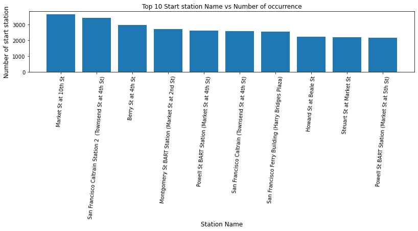

```python
#Subplot is called to plot the top 10 start stations.
subplot(top10_origin, top10_origin, 'Station Name', 'Number of start station', 'Top 10 Start station Name vs Number of occurrence')
```

```python
#Subplot is called to plot the top 10 start stations.
top10_dest = clean_bikes.end_station_name.value_counts()[0:10].sort_values(ascending=False)
top10_dest
```

```
San Francisco Caltrain Station 2  (Townsend St at 4th St)    4624
Market St at 10th St                                         3709
Montgomery St BART Station (Market St at 2nd St)             3461
San Francisco Ferry Building (Harry Bridges Plaza)           3151
San Francisco Caltrain (Townsend St at 4th St)               2870
Powell St BART Station (Market St at 4th St)                 2854
Berry St at 4th St                                           2782
The Embarcadero at Sansome St                                2341
Steuart St at Market St                                      2264
Powell St BART Station (Market St at 5th St)                 2153
Name: end_station_name, dtype: int64
```

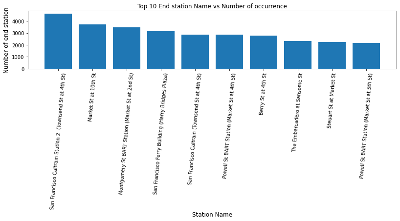

```python
subplot(top10_dest, top10_dest, 'Station Name', 'Number of end station', 'Top 10 End station Name vs Number of occurrence')
```

- From the above visualizations, San Francisco Caltrain Station 2 (Townsend St at 4th St) with 4624 occurrences is the most popular destination and the second most popular station with 3408 number where people originate their journey in the dataset.

#### We'll look into User types and number of occurrences

```python
clean_bikes.user_type.value_counts()
```

```
Subscriber    158386
Customer       16565
Name: user_type, dtype: int64
```

```python
(clean_bikes.user_type.value_counts() / clean_bikes.shape[0])*100
```

```
Subscriber    90.531635
Customer       9.468365
Name: user_type, dtype: float64
```

```python
# Creating a function for barplot
def barplot(x, y, xlabel, ylabel, title):
    ''' Plots a barplot of the x and y axes
    x = Data to be plotted
    y = Freqency
    xlabel= Label of x axes
    ylabel = Label of yaxes
    title = Title of Plot'''
    x= x
    y = y
    plt.bar(x, y)
    plt.xlabel(xlabel)
    plt.ylabel(ylabel)
    plt.title(title);
```

[figure not shown]

```python
#Using barplot on User_type frequency
barplot(clean_bikes['user_type'].unique(), clean_bikes['user_type'].value_counts(), 'User type', 'Frequency', 'Frequency of user type')
```

#### We can see that the subscribers are way more than the customers with subscribers accounting for over 90% of the dataset.

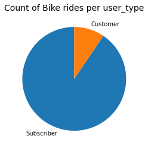

```python
# distribution via pie chart

plt.pie(clean_bikes['user_type'].value_counts(), labels = clean_bikes['user_type'].value_counts().index, startangle = 90);
plt.title('Count of Bike rides per user_type', fontsize=14);
```

- The above pie chart confirms that Subscribers take a larger chunk of the most users

#### Looking into frequency of each gender type

```
Male      130500
Female     40804
Other       3647
Name: member_gender, dtype: int64
```

[figure not shown]

```python
print(clean_bikes['member_gender'].value_counts())

barplot(clean_bikes['member_gender'].unique(), clean_bikes['member_gender'].value_counts(), 'Gender', 'Frequency', 'Gender vs Occurrence')
```

```python
(clean_bikes.member_gender.value_counts() / clean_bikes.shape[0])*100
```

```
Male      74.592314
Female    23.323102
Other      2.084584
Name: member_gender, dtype: float64
```

- Most of the bike riders are Males with the males being 74% of the dataset

### Discuss the distribution(s) of your variable(s) of interest. Were there any unusual points? Did you need to perform any transformations?

> Most of the riders are subscribers and within the ages of 20 and 60 also, trips are more during the weekdays (with more rides during opening and closing working hours) than on weekends this is painting a conclusion that most of the users of bikes are working class citizens who make use of bikes to get to their work.

### Of the features you investigated, were there any unusual distributions? Did you perform any operations on the data to tidy, adjust, or change the form of the data? If so, why did you do this?

> Age (created earlier in the dataset) is converted from Birth year, by substracting the year from the current year in review (2019). This gives us a distibution for age, this action is performed as age gives a better better perception regarding trip duration dependency. Also start station and end station is plotted in a larger plot because it gives a better insight regarding traffic of bikes at certain stations. Days of the week which was created earlier was also used in the analysis

### 5.2 Bivariate Exploration

> In this section, we'll look into relationship between age, gender and user type, days of the week, trip duration, station and duration

```python
clean_bikes.info()
```

```
<class 'pandas.core.frame.DataFrame'>
RangeIndex: 174951 entries, 0 to 174950
Data columns (total 22 columns):
 #   Column                   Non-Null Count   Dtype
---  ------                   --------------   -----
 0   duration_sec             174951 non-null  int64
 1   start_time               174951 non-null  object
 2   end_time                 174951 non-null  object
 3   start_station_id         174951 non-null  float64
 4   start_station_name       174951 non-null  object
 5   start_station_latitude   174951 non-null  float64
 6   start_station_longitude  174951 non-null  float64
 7   end_station_id           174951 non-null  float64
 8   end_station_name         174951 non-null  object
 9   end_station_latitude     174951 non-null  float64
 10  end_station_longitude    174951 non-null  float64
 11  bike_id                  174951 non-null  int64
 12  user_type                174951 non-null  object
 13  member_birth_year        174951 non-null  float64
 14  member_gender            174951 non-null  object
 15  bike_share_for_all_trip  174951 non-null  object
 16  duration_min             174951 non-null  float64
 17  Date                     174951 non-null  object
 18  Hour_of_day              174951 non-null  int64
 19  Day_of_week              174951 non-null  object
 20  Age                      174951 non-null  int64
 21  Hour_of day              0 non-null       category
dtypes: category(1), float64(8), int64(4), object(9)
memory usage: 28.2+ MB
```

#### I'll start with the breakdown of the gender and user_type

```python
#Counting the genders in each user type
use_gend = clean_bikes.groupby('user_type')['member_gender'].value_counts().sort_values(ascending= False)
use_gend
```

```
user_type   member_gender
Subscriber  Male             119007
            Female            36182
Customer    Male              11493
            Female             4622
Subscriber  Other              3197
Customer    Other               450
Name: member_gender, dtype: int64
```

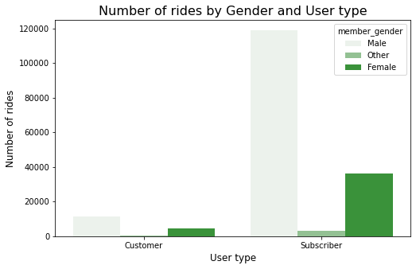

```python
plt.figure(figsize=(8,5))

sb.countplot(data=clean_bikes, x='user_type', hue='member_gender', color=base_color)
plt.xlabel('User type', fontsize=12)
plt.ylabel('Number of rides', fontsize=12)
plt.title("Number of rides by Gender and User type", fontsize=16);
```

- From the univariate exploration, we understood that the subscribers are more than the customers, here, we can see that all the respective genders in subscribers are more than customers.

#### How Age is spread with Trip duration

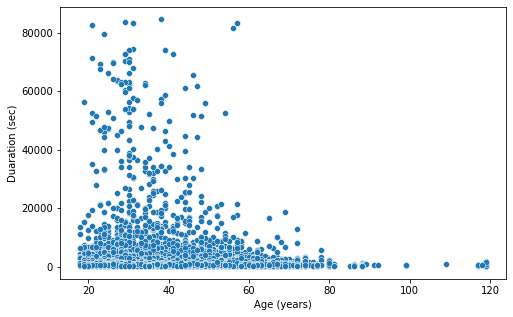

```python
plt.figure(figsize=[8,5])

sb.scatterplot(data = clean_bikes, x= 'Age', y= 'duration_sec')

plt.xlabel('Age (years)')
plt.ylabel('Duaration (sec)')
plt.show();
```

- From the above , we see that most of the trip durations are below 6000 secs and age of users below 80, we'll crop the plot to take indepth look at those values.

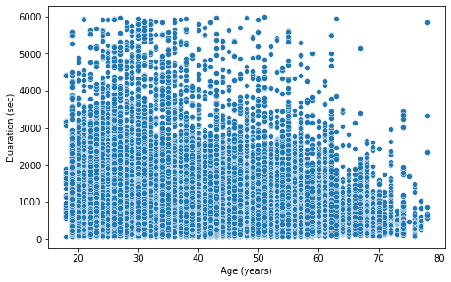

```python
plt.figure(figsize=[8,5])

selec_ages = clean_bikes.loc[clean_bikes['Age'] < 80]
x= selec_ages['Age']
sd = selec_ages.Age.value_counts
selecsec = clean_bikes.query("duration_sec < = 6000")
y = selecsec.duration_sec
sb.scatterplot(x, y)

plt.xlabel('Age (years)')
plt.ylabel('Duaration (sec)');
```

#### From the visualization above, we can see that most of the datapoints are concentrated below 3000 seconds (50 minutes); and most of the data is within the ages of 20 and 60.

#### Let's take a look into relationship between gender and duration

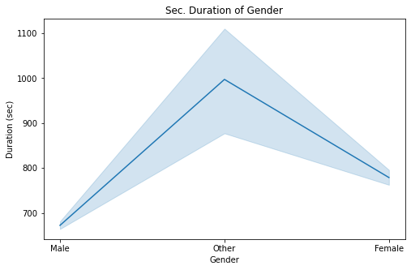

```python
#Line plot showing time spent on trips per gender
plt.figure(figsize = [8, 5])
sb.lineplot(data = clean_bikes, x = 'member_gender', y = 'duration_sec')
plt.xlabel('Gender')
plt.ylabel('Duration (sec)')
plt.title('Sec. Duration of Gender')
plt.show()
```

- Although we know that the number of rides by males and females exceeds Other gender, it is worthy of note that Other gender spend more time on trip than both males and females

```python
# Average time spent for each gender
gend_meandur = clean_bikes.groupby('member_gender')['duration_min'].mean().sort_values(ascending= False)
gend_meandur
```

```
member_gender
Other     16.622141
Female    12.980929
Male      11.206581
Name: duration_min, dtype: float64
```

#### Males averagely go on lesser trips than females and other with Other being the highest

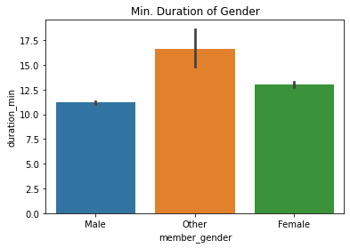

```python
# Plotting the gender of the users to the trip duration (mins)
sb.barplot(x='member_gender', y='duration_min', data=clean_bikes).set(title='Min. Duration of Gender');
```

- This further shows that males spend the least on duration of trips than others and females although there are more male users

#### Looking into user types and duration.

```python
# Grouping by user type to see the average of duration and number of each usertype.
usertype_dur = clean_bikes.groupby('user_type')['duration_min'].mean().sort_values(ascending= False)
use = clean_bikes['user_type'].value_counts()
usertype_dur, use
```

```
(user_type
 Customer      21.844104
 Subscriber    10.675855
 Name: duration_min, dtype: float64,
 Subscriber    158386
 Customer       16565
 Name: user_type, dtype: int64)
```

#### On an average, the Customer spends more time on the road than the Subscriber with 10 minutes although there are more Subscribers than Customers.

#### This would further depict that most of the customers are in the higher spectrum of the data

#### Looking at a barplot showing the user type trip duration:

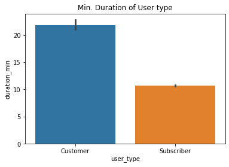

```python
# Plotting the user type of the members to duration of the trip
sb.barplot(x='user_type', y='duration_min', data=clean_bikes).set(title='Min. Duration of User type');
```

- The above visualization further shows that customers spend more time using bikes than Subscribers.

#### To further go deeper into the analysis, I'll show a boxplot of the dataset.

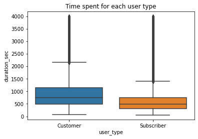

```python
#Box plot of trip duration of user type
x = clean_bikes['user_type']
s
df = clean_bikes.query("duration_sec < = 4000")
y = df.duration_sec
ax = sb.boxplot(x,y).set(title='Time spent for each user type');
```

> From the above visualization, I selected trip durations below 4000 secs (66.67 mins) , we can see that most of the Customers spend more time on trips than the subscribers.

#### Looking further into the number of user types on each day of the week.

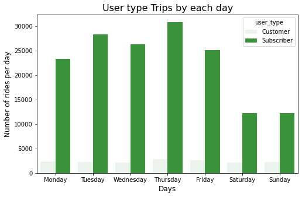

```python
# Count plot of showing the user type breakdown in days.
plt.figure(figsize=(8,5))

sb.countplot(data=clean_bikes, x='Day_of_week', hue='user_type', color=base_color)
plt.xlabel('Days', fontsize=12)
plt.ylabel('Number of rides per day', fontsize=12)
plt.title("User type Trips by each day", fontsize=16);
```

- Subcribers use bikes mostly during the weekdays while for customers, it is relatively the same all week.

#### To round up the Bivariate section, I would look into the trip duration in each day to see which day has the highest trip duration and later the correlation of Trip suration and Start Stations

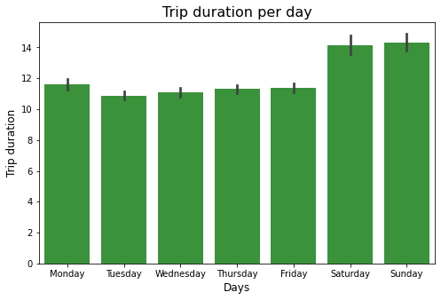

```python
#Bar plot showing the trip duration per day
plt.figure(figsize = [8, 5])
sb.barplot(data=clean_bikes, x='Day_of_week', y = 'duration_min', color=base_color)
plt.xlabel('Days', fontsize=12)
plt.ylabel('Trip duration', fontsize=12)
plt.title("Trip duration per day", fontsize=16);
```

#### From the visualization above, we can see that Saturdays and Sundays have more duration of trips than other days; this is an interesting situation, in previous analysis we have seen that week days are having the most trips but weekends are having the most durations, this could show that the users work place is not far from their origin station.

#### Trip Duration of start station

|  | duration_sec | start_station_id | start_station_latitude | start_station_longitude | end_station_id | end_station_latitude | end_station_longitude | bike_id | member_birth_year | duration_min | Hour_of_day | Age |
| --- | --- | --- | --- | --- | --- | --- | --- | --- | --- | --- | --- | --- |
| duration_sec | 1.000000 | -0.006874 | 0.012236 | -0.040945 | 0.002546 | 0.012855 | -0.041436 | 0.011034 | -0.006015 | 1.000000 | 0.006121 | 0.006015 |
| start_station_id | -0.006874 | 1.000000 | -0.195403 | 0.465129 | 0.339935 | -0.184319 | 0.472371 | -0.068107 | 0.115085 | -0.006874 | 0.013020 | -0.115085 |
| start_station_latitude | 0.012236 | -0.195403 | 1.000000 | -0.678105 | -0.184502 | 0.990131 | -0.683552 | 0.051138 | -0.075247 | 0.012236 | -0.017975 | 0.075247 |
| start_station_longitude | -0.040945 | 0.465129 | -0.678105 | 1.000000 | 0.485906 | -0.682599 | 0.992507 | -0.144056 | 0.125364 | -0.040945 | 0.053738 | -0.125364 |
| end_station_id | 0.002546 | 0.339935 | -0.184502 | 0.485906 | 1.000000 | -0.202502 | 0.475517 | -0.056812 | 0.112882 | 0.002546 | 0.091877 | -0.112882 |
| end_station_latitude | 0.012855 | -0.184319 | 0.990131 | -0.682599 | -0.202502 | 1.000000 | -0.685086 | 0.050508 | -0.075375 | 0.012855 | -0.034402 | 0.075375 |
| end_station_longitude | -0.041436 | 0.472371 | -0.683552 | 0.992507 | 0.475517 | -0.685086 | 1.000000 | -0.145892 | 0.126196 | -0.041436 | 0.034313 | -0.126196 |
| bike_id | 0.011034 | -0.068107 | 0.051138 | -0.144056 | -0.056812 | 0.050508 | -0.145892 | 1.000000 | 0.036309 | 0.011034 | 0.016892 | -0.036309 |
| member_birth_year | -0.006015 | 0.115085 | -0.075247 | 0.125364 | 0.112882 | -0.075375 | 0.126196 | 0.036309 | 1.000000 | -0.006015 | 0.064089 | -1.000000 |
| duration_min | 1.000000 | -0.006874 | 0.012236 | -0.040945 | 0.002546 | 0.012855 | -0.041436 | 0.011034 | -0.006015 | 1.000000 | 0.006121 | 0.006015 |
| Hour_of_day | 0.006121 | 0.013020 | -0.017975 | 0.053738 | 0.091877 | -0.034402 | 0.034313 | 0.016892 | 0.064089 | 0.006121 | 1.000000 | -0.064089 |
| Age | 0.006015 | -0.115085 | 0.075247 | -0.125364 | -0.112882 | 0.075375 | -0.126196 | -0.036309 | -1.000000 | 0.006015 | -0.064089 | 1.000000 |

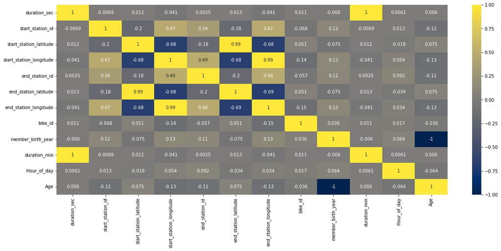

```python
plt.figure(figsize= (20,8))
c= clean_bikes.corr()
sb.heatmap(c, cmap = 'cividis', annot = True)
c
```

### Talk about some of the relationships you observed in this part of the investigation. How did the feature(s) of interest vary with other features in the dataset?

> The number of occurrence of a particular type of feature does not determine the time spent of the feature, on the other hand Start stations and end stations does not determine the trip duration.

### Did you observe any interesting relationships between the other features (not the main feature(s) of interest)?

> In the Univariate Exploration, I found out that the male gender has more number of trips than other genders, I expected this to also be the relationship in duration of trips, this is not the case as the other genders have a take longer trip times than the male gender. This is also the same with subscribers and customers.

### 5.3 Multivariate Exploration

> We'll follow on from duration of trips and number of trips both user types, genders and days in the dataframe.

```python
clean_bikes.info()
```

```
<class 'pandas.core.frame.DataFrame'>
RangeIndex: 174951 entries, 0 to 174950
Data columns (total 22 columns):
 #   Column                   Non-Null Count   Dtype
---  ------                   --------------   -----
 0   duration_sec             174951 non-null  int64
 1   start_time               174951 non-null  object
 2   end_time                 174951 non-null  object
 3   start_station_id         174951 non-null  float64
 4   start_station_name       174951 non-null  object
 5   start_station_latitude   174951 non-null  float64
 6   start_station_longitude  174951 non-null  float64
 7   end_station_id           174951 non-null  float64
 8   end_station_name         174951 non-null  object
 9   end_station_latitude     174951 non-null  float64
 10  end_station_longitude    174951 non-null  float64
 11  bike_id                  174951 non-null  int64
 12  user_type                174951 non-null  object
 13  member_birth_year        174951 non-null  float64
 14  member_gender            174951 non-null  object
 15  bike_share_for_all_trip  174951 non-null  object
 16  duration_min             174951 non-null  float64
 17  Date                     174951 non-null  object
 18  Hour_of_day              174951 non-null  int64
 19  Day_of_week              174951 non-null  category
 20  Age                      174951 non-null  int64
 21  Hour_of day              0 non-null       category
dtypes: category(2), float64(8), int64(4), object(8)
memory usage: 27.0+ MB
```

#### Let's begin with the duration each gender spent and the user types

```python
#Average time spent per gender within each user type
avr_gend_dur = clean_bikes.groupby(['user_type', 'member_gender'])['duration_sec'].mean().sort_values(ascending= False)
ave_gend_dur
```

[output not shown]

```python
#Total number of time spent per gender within each user type
tot_gend_dur = clean_bikes.groupby(['user_type', 'member_gender'])['duration_sec'].sum().sort_values(ascending= False)
tot_gend_dur
```

```
user_type   member_gender
Subscriber  Male             73339978
            Female           25198159
Customer    Male             14407550
            Female            6582270
Subscriber  Other             2916222
Customer    Other              721035
Name: duration_sec, dtype: int64
```

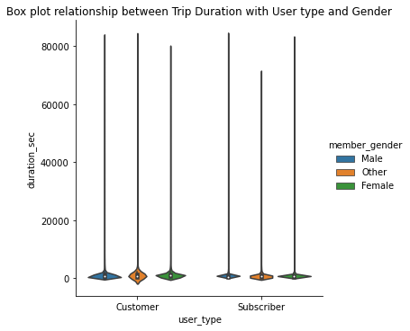

```python
#Plotting a boxplot of the trip duration against user type and gender
df = clean_bikes.melt(id_vars=['user_type', 'member_gender', 'duration_sec'])

sb.factorplot(data=df, x='user_type', y='duration_sec',
               hue='member_gender',
               kind='violin', legend=True).set(title='Box plot relationship between Trip Duration with User type and Gender')
plt.show();
```

> Let's see the spread using a strip plot

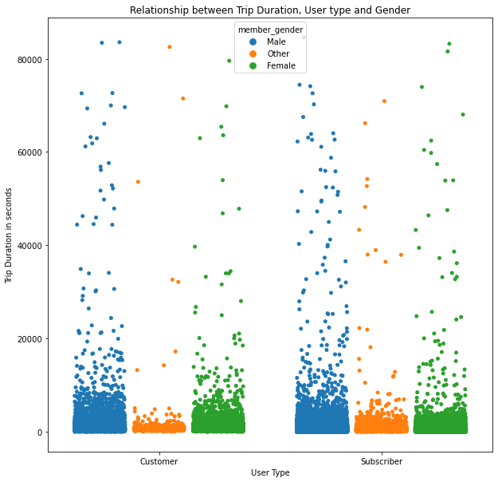

```python
# Visuallizing the relation between trip duration with user type and gender using strip plot
plt.figure(figsize =[10, 10])
sb.stripplot(data =clean_bikes, x="user_type", y="duration_sec", hue = 'member_gender', jitter= 0.34, dodge =True)
plt.title("Relationship between Trip Duration, User type and Gender")
plt.xlabel("User Type")
plt.ylabel("Trip Duration in seconds");
```

- From the above visualization, the Male Subscribers spend more time in trips than any other gender, (female subscribers and others). This also applies to the Customers
- This doesn't speak to the whole dataset as the other gender averagely spend more time on the road.

#### Daily user type trip durations

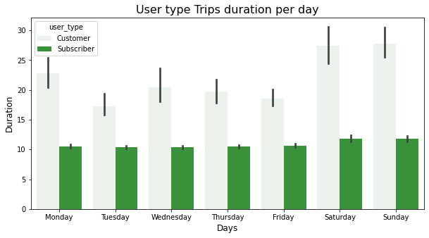

```python
# Barplot trip duration, usertype and days
plt.figure(figsize=(10, 5))
sb.barplot(data=clean_bikes, x='Day_of_week', hue='user_type', y = 'duration_min', color=base_color)
plt.xlabel('Days', fontsize=12)
plt.ylabel('Duration', fontsize=12)
plt.title("User type Trips duration per day", fontsize=16);
```

#### From the above visualization, Both User type spend more time on roads in the weekends than on weekdays, although the time customers spend on roads has a greater increase than time spent by Subscribers but with subscribers, it is almost the same time spent.

### Talk about some of the relationships you observed in this part of the investigation. Were there features that strengthened each other in terms of looking at your feature(s) of interest?

> Yes, in the Univariate exploration and bivariate, the subscribers had a higher number of trips than the customers, this was stengthened when broken down as all genders in subscribers had a higher number of trips than the customers.

### Were there any interesting or surprising interactions between features?

> It is interesring to know that both user types spend more time on trips during the weekends. Also, the increase in stime spent by the Customers during weekends increases significantly.

## 6. Conclusions

> The graphs reinforces the idea that more people tend to use bikes as a means of transportation on week days and the peak times are when they go to work and leave work, the use of bikes drastically reduces by weekends. (number)

> Subscribers mainly hire a bike during weekdays (more than double the level of weekends), while for Customers, they hire relatively the same number of trips all week round.

> It is very interesting to note that the duration of trips in the weekdays is significantly lower than on weekends in both the subscribers and Customers.

> The average bike trip duration of Customers is about the double of Subscribers(21 to 10 mis).

> Males subscribers spend more time on the road than other genders (other and females) but averagely, they spend less time on the road. This shows that most of the males durations fall in the lower spectrum.

```python
s
```